# Pinterest Analysis

### Initial Setup

Read in the data from the file:

```r
dat <- read.csv('pinterest_experiment.csv')
nrow(dat)
```

```
## [1] 753
```

How many duplicate responses do we have?

```r
summary(duplicated(dat["workerId"]))
```

```
##    Mode   FALSE    NA's
## logical     753       0
```

What are the column names?

```r
names(dat)
```

```
##  [1] "workerId"
##  [2] "Time_spent_page_1"
##  [3] "Time_spent_survey_1"
##  [4] "Condition"
##  [5] "Pin"
##  [6] "Pinterest.Which.of.the.following.social.media.platforms.do.you.have.an.account.on."
##  [7] "Instagram.Which.of.the.following.social.media.platforms.do.you.have.an.account.on."
##  [8] "Facebook.Which.of.the.following.social.media.platforms.do.you.have.an.account.on."
##  [9] "Twitter.Which.of.the.following.social.media.platforms.do.you.have.an.account.on."
## [10] "YouTube.Which.of.the.following.social.media.platforms.do.you.have.an.account.on."
## [11] "Snapchat.Which.of.the.following.social.media.platforms.do.you.have.an.account.on."
## [12] "Facebook.How.often.do.you.visit.each.of.the.following.social.media.platforms."
## [13] "Instagram.How.often.do.you.visit.each.of.the.following.social.media.platforms."
## [14] "Twitter.How.often.do.you.visit.each.of.the.following.social.media.platforms."
## [15] "Pinterest.How.often.do.you.visit.each.of.the.following.social.media.platforms."
```

[output cut: 35 more lines]

### Data Wrangling

Rename the columns:

```r
dat <- dat %>% rename(pin.impression = `What.is.your.overall.impression.of.the.pin.`,
                      item.impression = `After.observing.the.pin..what.is.your.overall.impression.of.the.item.shown.in.the.image.above.`,
                      creator.favors = `How.much.do.you.think.the.pin.creator.favors.the.item.shown.in.the.image.above.`,
                      relationship = `How.likely.do.you.think.there.is.a.relationship.between.the.pin.creator.and.the.organization.selling.the.item.`,
                      age = `In.which.year.were.you.born.`,
                      gender = `What.is.your.gender.`,
                      education = `What.is.the.highest.level.of.education.you.have.completed.`,
                      income = `What.is.your.annual.household.income.`,
                      account.pinterest = `Pinterest.Which.of.the.following.social.media.platforms.do.you.have.an.account.on.`,
                      visit.pinterest = `Pinterest.How.often.do.you.visit.each.of.the.following.social.media.platforms.`,
                      post.pinterest = `Pinterest.How.often.do.you.post.content.on.each.of.the.following.social.media.platforms.`)
```

Modify the demographics:

```r
dat <- dat %>% mutate(age = 2018 - age)
```

Change the relevant columns to factors:

```r
dat <- dat %>% mutate(Condition = factor(Condition),
                      Pin = factor(Pin),
                      PinId = factor(PinId))

levels(dat$Pin) <- c("Soap", "Seed", "Shoes", "Blanket", "Bed")
levels(dat$Condition) <- c("Control", "AffTop", "AffBottom", "ExplTop", "ExplBottom")
```

Create a new column indicating the disclosure type:

```r
dat <- dat %>% mutate(Disclosure = ifelse(Condition == "ExplTop" | Condition == "ExplBottom", "Expl", ifelse(Condition == "AffTop" | Condition == "AffBottom", "Aff", "Control")))
```

Change the relevant columns to numeric:

```r
summary(dat$pin.impression)
```

```
## Extremely Negative Extremely Positive            Neutral
##                 11                 98                256
##  Somewhat Negative  Somewhat Positive
##                 78                310
```

```r
dat <- dat %>% mutate(pin.impression = (factor(pin.impression, levels=c("Extremely Negative", "Somewhat Negative", "Neutral", "Somewhat Positive", "Extremely Positive"))))
summary(dat$pin.impression)
```

```
## Extremely Negative  Somewhat Negative            Neutral
##                 11                 78                256
##  Somewhat Positive Extremely Positive
##                310                 98
```

```r
dat <- dat %>% mutate(pin.impression_numeric = as.numeric(pin.impression))
summary(dat$pin.impression_numeric)
```

```
##    Min. 1st Qu.  Median    Mean 3rd Qu.    Max.
##   1.000   3.000   4.000   3.539   4.000   5.000
```

```r
summary(dat$item.impression)
```

```
## Extremely Negative Extremely Positive            Neutral
##                 21                 88                231
##  Somewhat Negative  Somewhat Positive
##                 95                318
```

```r
dat <- dat %>% mutate(item.impression = (factor(item.impression, levels=c("Extremely Negative", "Somewhat Negative", "Neutral", "Somewhat Positive", "Extremely Positive"))))
summary(dat$item.impression)
```

```
## Extremely Negative  Somewhat Negative            Neutral
##                 21                 95                231
##  Somewhat Positive Extremely Positive
##                318                 88
```

```r
dat <- dat %>% mutate(item.impression_numeric = as.numeric(item.impression))
summary(dat$item.impression)
```

```
## Extremely Negative  Somewhat Negative            Neutral
##                 21                 95                231
##  Somewhat Positive Extremely Positive
##                318                 88
```

```r
summary(dat$creator.favors)
```

```
## Does Not Favor At All     Moderately Favors       Slightly Favors
##                    28                   265                    62
##       Somewhat Favors       Strongly Favors
##                   154                   244
```

```r
dat <- dat %>% mutate(creator.favors = (factor(creator.favors, levels=c("Does Not Favor At All", "Slightly Favors", "Somewhat Favors", "Moderately Favors", "Strongly Favors"))))
summary(dat$creator.favors)
```

```
## Does Not Favor At All       Slightly Favors       Somewhat Favors
##                    28                    62                   154
##     Moderately Favors       Strongly Favors
##                   265                   244
```

```r
dat <- dat %>% mutate(creator.favors_numeric = as.numeric(creator.favors))
summary(dat$creator.favors)
```

```
## Does Not Favor At All       Slightly Favors       Somewhat Favors
##                    28                    62                   154
##     Moderately Favors       Strongly Favors
##                   265                   244
```

```r
summary(dat$relationship)
```

```
##   Extremely Likely Extremely Unlikely            Neutral
##                248                 32                117
##    Somewhat Likely  Somewhat Unlikely
##                281                 75
```

```r
dat <- dat %>% mutate(relationship = (factor(relationship, levels=c("Extremely Unlikely", "Somewhat Unlikely", "Neutral", "Somewhat Likely", "Extremely Likely"))))
summary(dat$relationship)
```

```
## Extremely Unlikely  Somewhat Unlikely            Neutral
##                 32                 75                117
##    Somewhat Likely   Extremely Likely
##                281                248
```

```r
dat <- dat %>% mutate(relationship_numeric = as.numeric(relationship))
summary(dat$relationship)
```

```
## Extremely Unlikely  Somewhat Unlikely            Neutral
##                 32                 75                117
##    Somewhat Likely   Extremely Likely
##                281                248
```

### User Demographics

How old were the users?

```r
summary(dat$age)
```

```
##    Min. 1st Qu.  Median    Mean 3rd Qu.    Max.
##   19.00   29.00   35.00   38.29   45.00  117.00
```

```r
sd(dat$age)
```

```
## [1] 12.49313
```

How were they distributed by gender?

```r
rowPerc(xtabs(~gender, data=dat))
```

```
##
## gender Female  Male Prefer not to answer Total
##         58.17 41.57                 0.27   100
```

How were they distributed by education?

```r
rowPerc(xtabs(~education, data=dat))
```

```
##
## education Associate's Degree Bachelor's Degree Doctoral Degree
##                        11.95             38.38             1.2
##
## education High School Graduate Master's Degree Prefer not to answer
##                           9.43           10.49                 0.53
##
## education Professional Degree (e.g., MBA, J.D.) Some College Total
##                                            3.19        24.83   100
```

How many users do we have in each condition across the survey?

```r
xtabs(~Condition + Pin, data=dat)
```

```
##             Pin
## Condition    Soap Seed Shoes Blanket Bed
##   Control      32   34    21      44  40
##   AffTop       27   23    28      41  24
##   AffBottom    28   29    33      27  31
##   ExplTop      40   30    25      31  23
##   ExplBottom   30   22    33      25  32
```

How many users do we have in each disclosure across the suvrey?

```r
xtabs(~Disclosure + Pin, data=dat)
```

```
##           Pin
## Disclosure Soap Seed Shoes Blanket Bed
##    Aff       55   52    61      68  55
##    Control   32   34    21      44  40
##    Expl      70   52    58      56  55
```

How many users vs non-users do we have?

```r
rowPerc(xtabs(~account.pinterest, data=dat))
```

```
##
## account.pinterest   No Not Sure   Yes Total
##                   15.8     1.73 82.47   100
```

How often do users visit Pinterest?

```r
rowPerc(xtabs(~visit.pinterest, data=dat))
```

```
##
## visit.pinterest A Few Times A Week About Once A Day Every Few Weeks
##                              29.75            18.06           15.67
##
## visit.pinterest Less Often Never Not Sure Several Times A Day Total
##                      10.76  9.16     0.66               15.94   100
```

How often do users post on Pinterest?

```r
rowPerc(xtabs(~post.pinterest, data=dat))
```

```
##
## post.pinterest A Few Times A Week About Once A Day Every Few Weeks
##                             16.87              7.3            15.8
##
## post.pinterest Less Often Never Not Sure Several Times A Day Total
##                     17.93 35.06      0.4                6.64   100
```

Let’s write a simple graphing utility.

```r
likert_plot <- function(data, pin_factor, col) {
  filt_data <- data %>% filter(Pin == pin_factor)
  cols <- c(col)
  cols <- setNames(cols, c(pin_factor))
  likert_data <- likert(filt_data %>% select(col) %>% rename_(.dots=cols), grouping=filt_data$Condition)
  return(plot(likert_data, centered=FALSE, legend.position="none"))
}

grid_likert_plot <- function(data, col) {
  p1 <- likert_plot(data, "Soap", col)
  p2 <- likert_plot(data, "Seed", col)
  p3 <- likert_plot(data, "Shoes", col)
  p4 <- likert_plot(data, "Blanket", col)
  p5 <- likert_plot(data, "Bed", col)

  return(grid.arrange(p1, p2, p3, p4, p5))
}

likert_plot_combined <- function(data, col) {
  likert_data <- likert(data %>% select(col), grouping=data$Condition)
  return(plot(likert_data, centered=FALSE, legend.position="none"))
}
```

Let’s also write a utility that will generate the logit plot.

```r
po_plot_helper <- function(data, pin_factor, col) {
  filt_data <- data %>% filter(Pin == pin_factor)
  mat <- as.data.frame.matrix(xtabs(formula(paste0("~Condition + ", col)), filt_data))

  new_mat <- matrix(nrow=5, ncol=4)

  for(i in 1:4) {
     first_set <- mat[, c(1:i)]
     second_set <- mat[, c((i+1):5)]

     if(!is.null(dim(first_set))) {
        first_set <- as.integer(rowSums(first_set))
     }

      if(!is.null(dim(second_set))) {
        second_set <- as.integer(rowSums(second_set))
     }

     result = log(first_set/second_set)

     new_mat[, i] <- result
  }

  rownames(new_mat) <- rownames(mat)
  return(ggplot(melt(new_mat), aes(x=Var1, y=value, col=factor(Var2), group=factor(Var2))) + geom_line() + xlab("Condition") + ylab("Logits") + theme(axis.text.x = element_text(angle = 45, hjust = 1), legend.position="none") + ggtitle(pin_factor))
}

po_plot <- function(data, col) {
  p1 <- po_plot_helper(data, "Soap", col)
  p2 <- po_plot_helper(data, "Seed", col)
  p3 <- po_plot_helper(data, "Shoes", col)
  p4 <- po_plot_helper(data, "Blanket", col)
  p5 <- po_plot_helper(data, "Bed", col)

  return(grid.arrange(p1, p2, p3, p4, p5))
}
```

### What is your overall impression of the pin?

Let’s first examine the distribution of this question across the different pins.

```r
xtabs(~Condition + pin.impression, data=dat)
```

```
##             pin.impression
## Condition    Extremely Negative Somewhat Negative Neutral
##   Control                     2                20      58
##   AffTop                      1                13      54
##   AffBottom                   4                14      54
##   ExplTop                     3                18      46
##   ExplBottom                  1                13      44
##             pin.impression
## Condition    Somewhat Positive Extremely Positive
##   Control                   70                 21
##   AffTop                    63                 12
##   AffBottom                 57                 19
##   ExplTop                   62                 20
##   ExplBottom                58                 26
```

Let’s visualize the data.

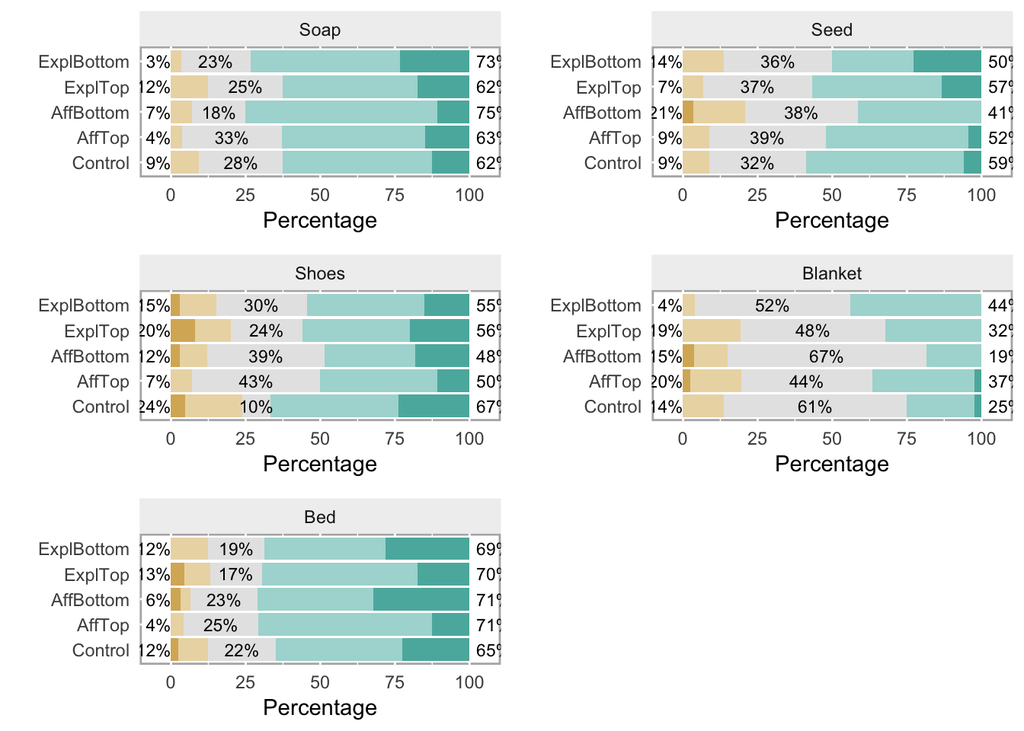

```r
grid_likert_plot(dat, "pin.impression")
```

Let’s visualize the logits.

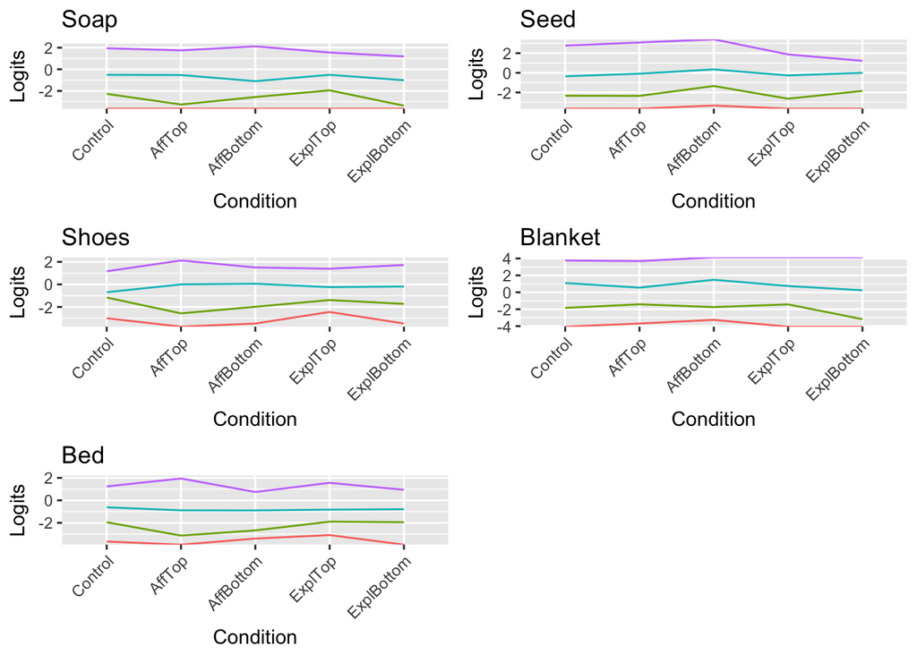

```r
po_plot(dat, "pin.impression")
```

Next, let’s build a ordinal regression model.

```r
model <- clmm2(pin.impression ~ Condition, random=Pin, data=dat, Hess = TRUE)
summary(model)
```

```
## Cumulative Link Mixed Model fitted with the Laplace approximation
##
## Call:
## clmm2(location = pin.impression ~ Condition, random = Pin, data = dat,
##     Hess = TRUE)
##
## Random effects:
##           Var   Std.Dev
## Pin 0.2357799 0.4855717
##
## Location coefficients:
##                     Estimate Std. Error z value  Pr(>|z|)
## ConditionAffTop      -0.0235   0.2077    -0.1129 0.91008
## ConditionAffBottom   -0.0864   0.2084    -0.4147 0.67839
## ConditionExplTop      0.0111   0.2096     0.0529 0.95781
## ConditionExplBottom   0.2576   0.2139     1.2045 0.22839
##
## No scale coefficients
##
## Threshold coefficients:
##                                      Estimate Std. Error z value
## Extremely Negative|Somewhat Negative  -4.3350   0.3954   -10.9642
## Somewhat Negative|Neutral             -2.1214   0.2769    -7.6615
## Neutral|Somewhat Positive             -0.1881   0.2621    -0.7174
## Somewhat Positive|Extremely Positive   1.9995   0.2744     7.2866
##
## log-likelihood: -951.3676
## AIC: 1920.735
## Condition number of Hessian: 73.99676
```

```r
exp(coef(model))
```

```
## Extremely Negative|Somewhat Negative            Somewhat Negative|Neutral
##                            0.0131023                            0.1198634
##            Neutral|Somewhat Positive Somewhat Positive|Extremely Positive
##                            0.8285702                            7.3856888
##                      ConditionAffTop                   ConditionAffBottom
##                            0.9768190                            0.9172076
##                     ConditionExplTop                  ConditionExplBottom
##                            1.0111508                            1.2938117
##
##                            1.6251039
```

```r
exp(confint.default(model))
```

```
##                                            2.5 %      97.5 %
## Extremely Negative|Somewhat Negative 0.006036742  0.02843757
## Somewhat Negative|Neutral            0.069662268  0.20624143
## Neutral|Somewhat Positive            0.495687339  1.38500320
## Somewhat Positive|Extremely Positive 4.313291872 12.64658190
## ConditionAffTop                      0.650202201  1.46750573
## ConditionAffBottom                   0.609624625  1.37998011
## ConditionExplTop                     0.670480442  1.52491545
## ConditionExplBottom                  0.850817940  1.96745832
##                                               NA          NA
```

### What is your overall impression of the item?

Let’s first examine the distribution of this question across the different pins.

```r
xtabs(~Condition + item.impression, data=dat)
```

```
##             item.impression
## Condition    Extremely Negative Somewhat Negative Neutral
##   Control                     5                27      49
##   AffTop                      1                15      44
##   AffBottom                   4                14      45
##   ExplTop                     5                25      49
##   ExplBottom                  6                14      44
##             item.impression
## Condition    Somewhat Positive Extremely Positive
##   Control                   76                 14
##   AffTop                    63                 20
##   AffBottom                 65                 20
##   ExplTop                   53                 17
##   ExplBottom                61                 17
```

Let’s visualize the data.

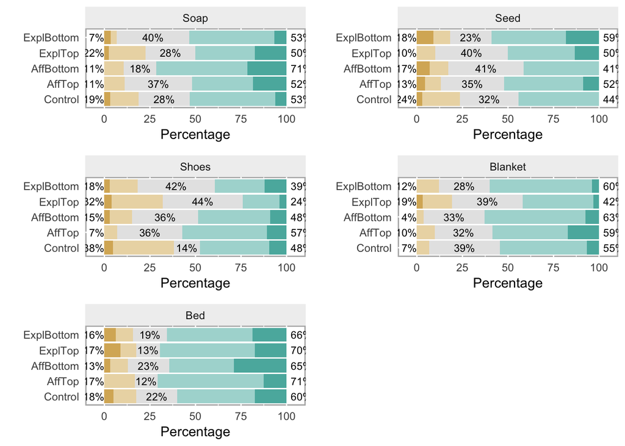

```r
grid_likert_plot(dat, "item.impression")
```

Let’s visualize the logits.

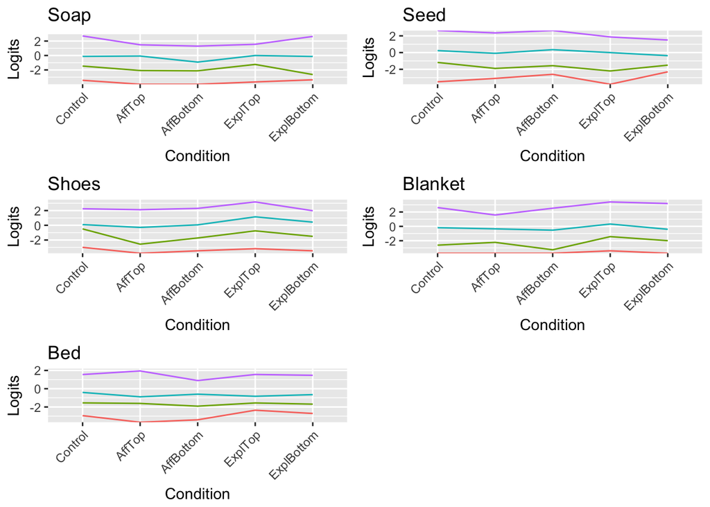

```r
po_plot(dat, "item.impression")
```

Next, let’s build a ordinal regression model.

```r
model <- clmm2(item.impression ~ Condition, random=Pin, data=dat, Hess = TRUE)
summary(model)
```

```
## Cumulative Link Mixed Model fitted with the Laplace approximation
##
## Call:
## clmm2(location = item.impression ~ Condition, random = Pin, data = dat,
##     Hess = TRUE)
##
## Random effects:
##            Var   Std.Dev
## Pin 0.06122337 0.2474336
##
## Location coefficients:
##                     Estimate Std. Error z value  Pr(>|z|)
## ConditionAffTop       0.3998   0.2090     1.9130 0.055744
## ConditionAffBottom    0.3649   0.2076     1.7577 0.078791
## ConditionExplTop     -0.0684   0.2070    -0.3303 0.741148
## ConditionExplBottom   0.2166   0.2099     1.0321 0.302040
##
## No scale coefficients
##
## Threshold coefficients:
##                                      Estimate Std. Error z value
## Extremely Negative|Somewhat Negative  -3.4133   0.2753   -12.3972
## Somewhat Negative|Neutral             -1.5545   0.1934    -8.0369
## Neutral|Somewhat Positive              0.0195   0.1819     0.1071
## Somewhat Positive|Extremely Positive   2.2385   0.2045    10.9447
##
## log-likelihood: -1001.219
## AIC: 2020.437
## Condition number of Hessian: 58.66341
```

```r
exp(coef(model))
```

```
## Extremely Negative|Somewhat Negative            Somewhat Negative|Neutral
##                           0.03293149                           0.21129954
##            Neutral|Somewhat Positive Somewhat Positive|Extremely Positive
##                           1.01966371                           9.37883054
##                      ConditionAffTop                   ConditionAffBottom
##                           1.49158100                           1.44036173
##                     ConditionExplTop                  ConditionExplBottom
##                           0.93389148                           1.24186032
##
##                           1.28073426
```

```r
exp(confint.default(model))
```

```
##                                           2.5 %      97.5 %
## Extremely Negative|Somewhat Negative 0.01919769  0.05649028
## Somewhat Negative|Neutral            0.14463104  0.30869926
## Neutral|Somewhat Positive            0.71391087  1.45636399
## Somewhat Positive|Extremely Positive 6.28142062 14.00359373
## ConditionAffTop                      0.99023873  2.24674498
## ConditionAffBottom                   0.95889025  2.16358639
## ConditionExplTop                     0.62238153  1.40131616
## ConditionExplBottom                  0.82304332  1.87379815
##                                              NA          NA
```

### How much do you think the creator favors the item?

Let’s first examine the distribution of this question across the different pins.

```r
xtabs(~Condition + creator.favors, data=dat)
```

```
##             creator.favors
## Condition    Does Not Favor At All Slightly Favors Somewhat Favors
##   Control                        3               8              31
##   AffTop                         4              13              29
##   AffBottom                      5               7              21
##   ExplTop                        6              22              36
##   ExplBottom                    10              12              37
##             creator.favors
## Condition    Moderately Favors Strongly Favors
##   Control                   60              69
##   AffTop                    58              39
##   AffBottom                 63              52
##   ExplTop                   45              40
##   ExplBottom                39              44
```

Let’s visualize the data.

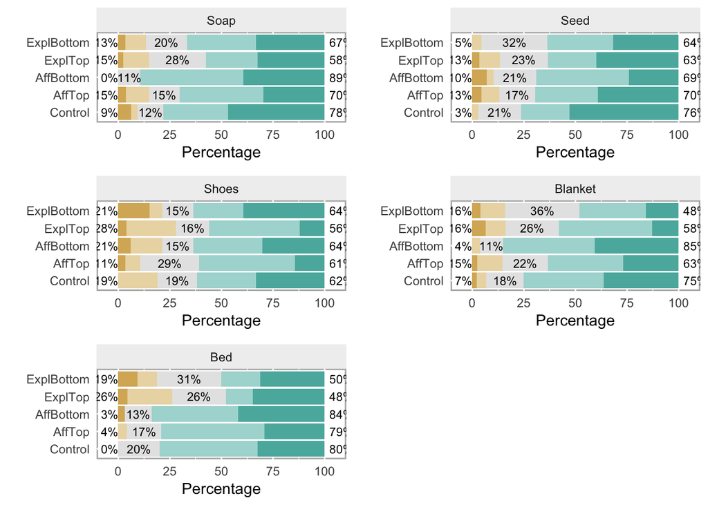

```r
grid_likert_plot(dat, "creator.favors")
```

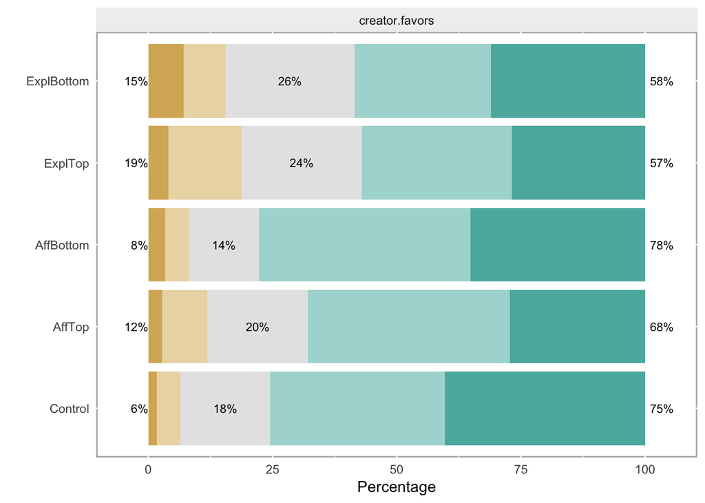

```r
likert_plot_combined(dat, "creator.favors")
```

Let’s visualize the logits.

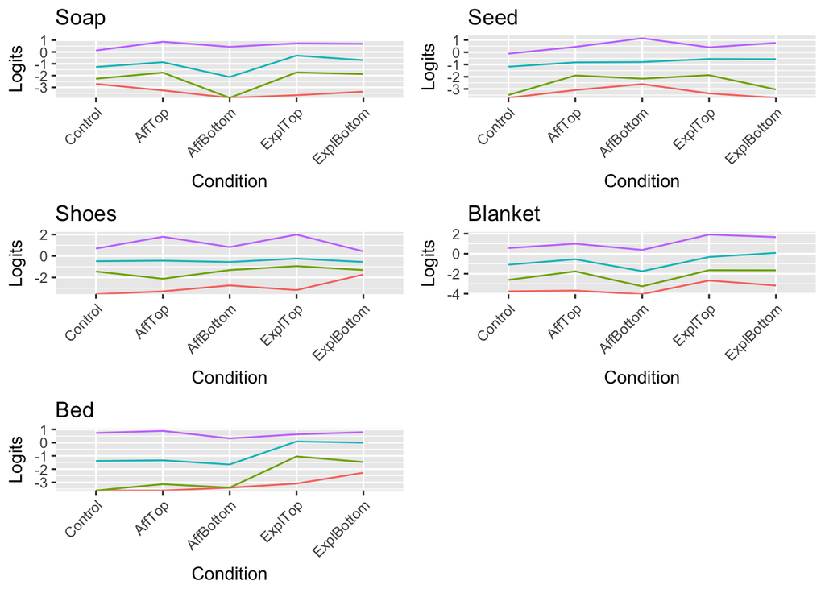

```r
po_plot(dat, "creator.favors")
```

Next, let’s build a ordinal regression model.

```r
model <- clmm2(creator.favors ~ Condition, random=Pin, data=dat, Hess = TRUE)
summary(model)
```

```
## Cumulative Link Mixed Model fitted with the Laplace approximation
##
## Call:
## clmm2(location = creator.favors ~ Condition, random = Pin, data = dat,
##     Hess = TRUE)
##
## Random effects:
##            Var   Std.Dev
## Pin 0.01412501 0.1188487
##
## Location coefficients:
##                     Estimate Std. Error z value  Pr(>|z|)
## ConditionAffTop      -0.4707   0.2056    -2.2894 0.02205518
## ConditionAffBottom   -0.1023   0.2036    -0.5023 0.61549081
## ConditionExplTop     -0.7824   0.2073    -3.7753 0.00015983
## ConditionExplBottom  -0.6410   0.2109    -3.0391 0.00237288
##
## No scale coefficients
##
## Threshold coefficients:
##                                       Estimate Std. Error z value
## Does Not Favor At All|Slightly Favors  -3.6879   0.2401   -15.3623
## Slightly Favors|Somewhat Favors        -2.4181   0.1807   -13.3803
## Somewhat Favors|Moderately Favors      -1.1284   0.1584    -7.1218
## Moderately Favors|Strongly Favors       0.3775   0.1536     2.4569
##
## log-likelihood: -1032.194
## AIC: 2082.388
## Condition number of Hessian: 253.0001
```

```r
exp(coef(model))
```

```
## Does Not Favor At All|Slightly Favors
##                            0.02502390
##       Slightly Favors|Somewhat Favors
##                            0.08908688
##     Somewhat Favors|Moderately Favors
##                            0.32355429
##     Moderately Favors|Strongly Favors
##                            1.45858474
##                       ConditionAffTop
##                            0.62458279
##                    ConditionAffBottom
##                            0.90279353
##                      ConditionExplTop
##                            0.45729058
##                   ConditionExplBottom
##                            0.52677826
##
##                            1.12619949
```

```r
exp(confint.default(model))
```

```
##                                            2.5 %     97.5 %
## Does Not Favor At All|Slightly Favors 0.01563192 0.04005878
## Slightly Favors|Somewhat Favors       0.06251453 0.12695406
## Somewhat Favors|Moderately Favors     0.23718166 0.44138058
## Moderately Favors|Strongly Favors     1.07933727 1.97108866
## ConditionAffTop                       0.41744099 0.93451211
## ConditionAffBottom                    0.60572939 1.34554502
## ConditionExplTop                      0.30463431 0.68644491
## ConditionExplBottom                   0.34841836 0.79644292
##                                               NA         NA
```

### How likely do you think there is a relationship between the content creator and the merchant?

Let’s first examine the distribution of this question across the different pins.

```r
xtabs(~Condition + relationship, data=dat)
```

```
##             relationship
## Condition    Extremely Unlikely Somewhat Unlikely Neutral Somewhat Likely
##   Control                     6                15      41              74
##   AffTop                      8                16      25              54
##   AffBottom                  10                19      20              60
##   ExplTop                     4                12      18              48
##   ExplBottom                  4                13      13              45
##             relationship
## Condition    Extremely Likely
##   Control                  35
##   AffTop                   40
##   AffBottom                39
##   ExplTop                  67
##   ExplBottom               67
```

Let’s visualize the data.

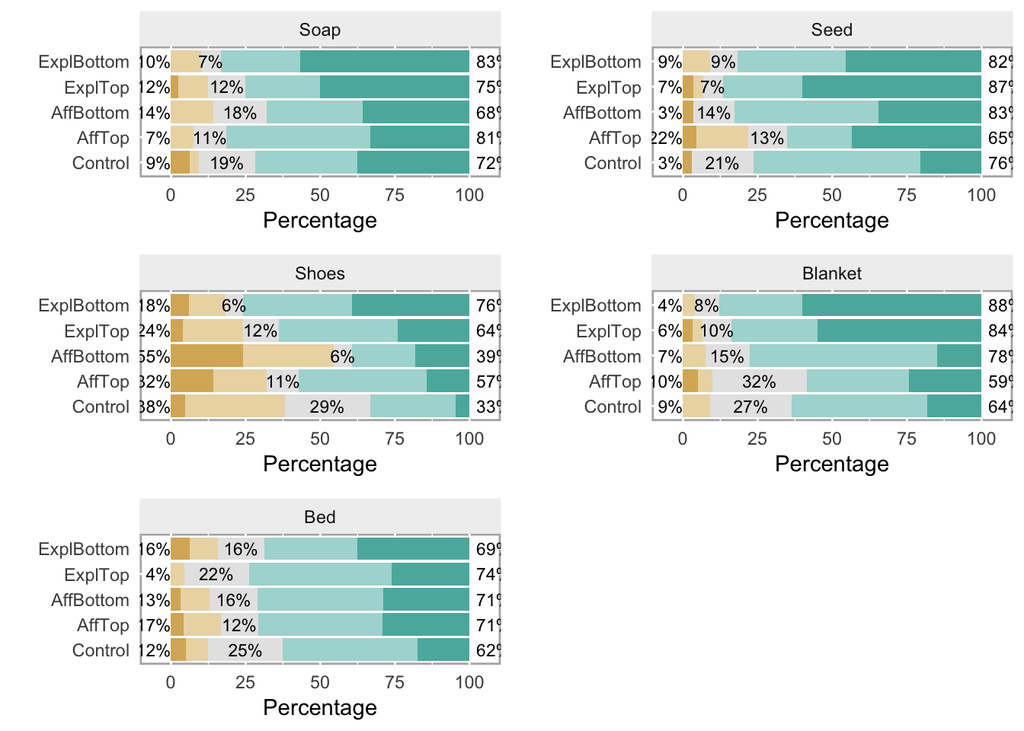

```r
grid_likert_plot(dat, "relationship")
```

Let’s visualize the logits.

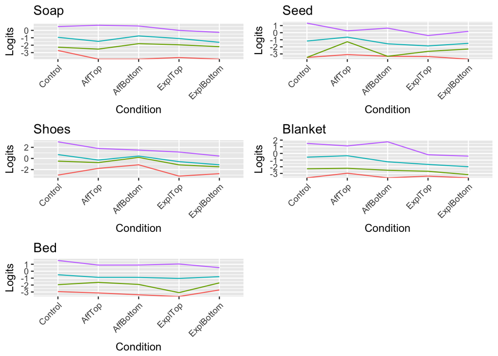

```r
po_plot(dat, "relationship")
```

Next, let’s build a ordinal regression model.

```r
model <- clmm2(relationship ~ Condition, random=Pin, data=dat, Hess = TRUE, link="logistic")
summary(model)
```

```
## Cumulative Link Mixed Model fitted with the Laplace approximation
##
## Call:
## clmm2(location = relationship ~ Condition, random = Pin, data = dat,
##     Hess = TRUE, link = "logistic")
##
## Random effects:
##           Var   Std.Dev
## Pin 0.1950984 0.4416995
##
## Location coefficients:
##                     Estimate Std. Error z value Pr(>|z|)
## ConditionAffTop      0.1923   0.2040     0.9427 0.345858
## ConditionAffBottom   0.1229   0.2006     0.6128 0.540007
## ConditionExplTop     0.8648   0.2072     4.1748 2.9830e-05
## ConditionExplBottom  1.0376   0.2139     4.8502 1.2331e-06
##
## No scale coefficients
##
## Threshold coefficients:
##                                      Estimate Std. Error z value
## Extremely Unlikely|Somewhat Unlikely -2.8383   0.2908    -9.7593
## Somewhat Unlikely|Neutral            -1.4739   0.2498    -5.9001
## Neutral|Somewhat Likely              -0.4857   0.2414    -2.0124
## Somewhat Likely|Extremely Likely      1.1985   0.2457     4.8777
##
## log-likelihood: -1013.747
## AIC: 2045.494
## Condition number of Hessian: 96.98806
```

```r
exp(coef(model))
```

```
## Extremely Unlikely|Somewhat Unlikely            Somewhat Unlikely|Neutral
##                           0.05852693                           0.22903226
##              Neutral|Somewhat Likely     Somewhat Likely|Extremely Likely
##                           0.61526010                           3.31502245
##                      ConditionAffTop                   ConditionAffBottom
##                           1.21198992                           1.13077760
##                     ConditionExplTop                  ConditionExplBottom
##                           2.37462985                           2.82234836
##
##                           1.55534829
```

```r
exp(confint.default(model))
```

```
##                                           2.5 %    97.5 %
## Extremely Unlikely|Somewhat Unlikely 0.03309809 0.1034924
## Somewhat Unlikely|Neutral            0.14036567 0.3737080
## Neutral|Somewhat Likely              0.38336257 0.9874334
## Somewhat Likely|Extremely Likely     2.04807161 5.3657176
## ConditionAffTop                      0.81262096 1.8076319
## ConditionAffBottom                   0.76323392 1.6753160
## ConditionExplTop                     1.58220019 3.5639402
## ConditionExplBottom                  1.85575390 4.2924066
##                                              NA        NA
```